# Free Speech on College Campuses

Independent unsupervised learning project. The goals are

1. to attempt to recover a latent variable representing political correctness,
2. to see if students can be clustered by their positions on free speech, and
3. to assess the relationship between such clusters or latent variables and students' political affiliations.

The notebook is organized in roughly the order the goals are listed. At the beginning and end of the notebook there is additional data exploration. I also include some Markdown that helps guide users along the CRISP-DM approach to organizing the data analysis process:

1. Business Understanding
2. Data Understanding
3. Prepare Data
4. Data Modeling
5. Evaluate the Results

## Business Understanding

College students once led the nation in the push for free speech rights. Now some political pundits--especially Conservative pundits--have expressed concern that college students are leading the fight *against* free speech. The claim is that students are fighting hate speech in the name of inclusiveness, and in doing so are reducing the window of acceptable expression. Everyone dislikes hate speech and everyone likes inclusiveness, so what's the big deal? Well, it matters how students define "hate speech".

Students have rioted at the presence of popular, provocative conservative figures who hold mainstream conservative views. The best example is Ben Shapiro, whose views are something like a socially liberal version of Reaganism. Shapiro is popular among young conservatives, but despised by young liberals. Some young liberals consider Shapiro a "hateful" person because their moral principles differ so starkly.

Gallup and the Knight Foundation recently co-sponsored a survey of college students on their beliefs about free speech. They made that data available to the public. You can learn more here: https://heterodoxacademy.org/gallup-knight-foundation-study/

I sought to see if I could recover a latent variable called "Political Correctness", defined as the preference for reduction in free speech rights in order to increase inclusivitity. The concept of Political Correctness is at the heart of Conservative pundits' concerns, to the extent that students favor "unreasonable" restrictions on first amendment rights.

I also sought to see if students could be clustered by their views on free speech. Are students cleanly divided on the issue? Or is the distribution variance just a bit larger than it used to be?

Finally, I explored the relationship between free speech beliefs and self-identified political ideology. The exploration helps us understand the extent to which differences in free speech beliefs are actually political, or the extent to which differences in those beliefs can be conflated with existing political divisions.

## Data Undersstanding

The dataset consists of survey responses from 3,014 colleges students.

The 14 variables associated with questions used in the Stanton Free Speech Index, discussed later, are used to index students' free speech views. These variables are used for latent variable analysis and cluster analysis.

The data also includes several variables describing students' responses to demographic questions, such as socioeconomic status and age. These variables are included as covariates in regression models used to explore the relationships between free speech beliefs and political affiliations.

The data includes variables describing students' responses to questions bout their political ideological leaning and political party leanings. These are used as response variables in the regression models.

The data also includes survey weights.

```python
#Import libraries
import numpy as np
import pandas as pd
import matplotlib.pyplot as plt
from mpl_toolkits import mplot3d
import seaborn as sns
from sklearn.impute import SimpleImputer
from sklearn.preprocessing import StandardScaler
from sklearn.decomposition import PCA
from sklearn.cluster import KMeans, DBSCAN, AgglomerativeClustering
from sklearn.mixture import GaussianMixture
from sklearn.metrics import silhouette_score, calinski_harabaz_score, make_scorer
from sklearn.model_selection import GridSearchCV, train_test_split
import statsmodels.api as sm
from scipy.stats import ttest_ind
```

## Read in data

```python
# Read in Stata .dta file
raw_data = pd.read_stata('GallupKnight-Foundation-2017-College-Student-Free-Speech-and-Expression-HxA-Data-Analyst-Database.dta')
```

## Preprocess (prepare) data

```python
def clean_data(raw_data):
    ''' Cleans data, handles missing values, and encodes dummies.

    Args:
    raw_data: Pandas DataFrame. The raw data imported from csv copy of survey results.

    Returns:
    fs_df: Pandas DataFrame. Contains formatted feature variables, excluding FS_Index.
    y: Pandas DataFrame. Contains response variable dummies.
    wt: Pandas Series. Contains survey weights.
    FS_Index: Pandas Series. Contains Stanton Free Speech Index variable.

    '''

    fs_df = raw_data[['ageban', 'genderban', 'relban', 'soc_classrec', 'arearec',
                      'Race_Black', 'Race_Hispanic', 'Race_Asian', 'Race_Other',
                      'Region_East', 'Region_MidWest', 'Region_South',
                      'Institution_Public',
                      'FSI_Q4', 'FSI_Q4A', 'FSI_Q14A', 'FSI_Q14B', 'FSI_Q34A',
                      'FSI_Q34B', 'FSI_Q34D', 'FSI_Q34E', 'FSI_Q34F', 'FSI_Q35A',
                      'FSI_Q35C', 'FSI_Q35D', 'FSI_Q40B', 'FSI_Q41', 'FSI_Q43',
                      'PARTYL', 'ideolrec', 'finalwt', 'FS_Index', 'D10']].copy()

    # Drop if missing response variable(s)
    fs_df = fs_df.dropna(subset=['PARTYL', 'ideolrec', 'D10'])

    # Separate response, feature, and survey weight variables
    y = fs_df[['PARTYL', 'ideolrec', 'D10']].copy()
    wt = 1 / fs_df['finalwt'].copy()
    FS_Index = fs_df['FS_Index'].copy().astype('float')
    fs_df = fs_df.drop(columns=['PARTYL', 'ideolrec', 'finalwt', 'FS_Index', 'D10'])

    # Combine Q4 and Q4A into one variable, per the data dictionary guideline
    fs_df['FSI_Q4'].replace(np.nan, fs_df['FSI_Q4A'], inplace=True)
    fs_df = fs_df.drop(columns=['FSI_Q4A'])
    fs_df['FSI_Q4'].replace(['An open learning environment', 'A positive learning environment',
                             'Allow all types of speech', 'Prohibit offensive speech'],
                            ['1', '0', '1', '0'], inplace=True)
    fs_df['FSI_Q4'] = pd.to_numeric(fs_df['FSI_Q4'])

    # I am grouping those with no religion with those who are agnostic
    fs_df['relban'].replace('No opinion', 'No religion', inplace=True)

    # Replace "No opinon" with np.nan for variables that are not subjective
    fs_df['soc_classrec'].replace('No opinion', np.nan, inplace=True)
    fs_df['arearec'].replace('No opinion', np.nan, inplace=True)

    # Replace string labels with integers in FSI variables to make sure 1 = free speech and 0 = protective policies
    # This will facilitate mean imputation
    cat_cols = fs_df.select_dtypes(['category']).columns
    fs_df[cat_cols] = fs_df[cat_cols].apply(lambda x: x.cat.codes)
    fs_df['FSI_Q34A'].replace([0, 1, 2, -1], [0, 0.5, 1, np.nan], inplace=True)
    fs_df['FSI_Q34B'].replace([0, 1, 2, -1], [0, 0.5, 1, np.nan], inplace=True)
    fs_df['FSI_Q34D'].replace([0, 1, 2, -1], [0, 0.5, 1, np.nan], inplace=True)
    fs_df['FSI_Q34E'].replace([0, 1, 2, -1], [0, 0.5, 1, np.nan], inplace=True)
    fs_df['FSI_Q34F'].replace([0, 1, 2, -1], [0, 0.5, 1, np.nan], inplace=True)
    fs_df['FSI_Q40B'].replace([0, 1, 2, 3, -1], [0, 0.33, 0.66, 1, np.nan], inplace=True)
    fs_df.replace(-1, np.nan, inplace=True)
    fs_df['FSI_Q43'] = fs_df['FSI_Q43'].copy() * -1 + 1 # reversing the 0 and 1

    # Impute missing values of categorical variables with mode
    fs_df[['soc_classrec', 'arearec']] = SimpleImputer(strategy='most_frequent').fit_transform(fs_df[['soc_classrec', 'arearec']])

    # Impute missing values of ordinal variables with mean
    fs_df = pd.DataFrame(SimpleImputer().fit_transform(fs_df), columns=fs_df.columns)

    # Get dummies
    fs_df = pd.get_dummies(fs_df, columns=['genderban', 'relban', 'soc_classrec', 'arearec'], drop_first=True)

    # Do cool things with response variables
    y = pd.get_dummies(y, drop_first=False)
    y = y.drop(columns=['PARTYL_Libertarian', 'PARTYL_No opinion', 'ideolrec_DK', 'ideolrec_REF', 'D10_No opinion'])

    return fs_df, y, wt, FS_Index
```

## Exploration: A quick look at the Free Speech Index

The Stanton Foundation Free Speech Index (FSI) value for each student is the sum of their values for the variables prefixed by 'FSI_'.

The FSI appears to be approximately normally distributed among students as a whole, but distributions differ when conditioned on ideology or political party affiliation.

```python
# Get data
df, y, wt, FS_Index = clean_data(raw_data)

# Create separate arrays for each outcome (makes graphing easier)
lib_fsi = FS_Index[y.loc[:,'ideolrec_Liberal'] == 1]
cons_fsi = FS_Index[y.loc[:,'ideolrec_Conservative'] == 1]
mod_fsi = FS_Index[y.loc[:, 'ideolrec_Moderate'] == 1]

dem_fsi = FS_Index[y.loc[:,'PARTYL_Democrat/lean Democrat'] == 1]
rep_fsi = FS_Index[y.loc[:,'PARTYL_Republican/lean Republican'] == 1]
ind_fsi = FS_Index[y.loc[:, 'PARTYL_Independent/no lean'] == 1]

very_lib_fsi = FS_Index[y.loc[:,'D10_Very liberal'] == 1]
some_lib_fsi = FS_Index[y.loc[:,'D10_Liberal'] == 1]
very_cons_fsi = FS_Index[y.loc[:,'D10_Very conservative'] == 1]
some_cons_fsi = FS_Index[y.loc[:,'D10_Conservative'] == 1]
d10_mod_fsi = FS_Index[y.loc[:, 'D10_Moderate'] == 1]
```

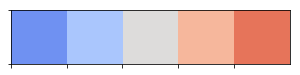

```python
# Seaborn colors I will use
sns.palplot(sns.color_palette('coolwarm', 5))
```

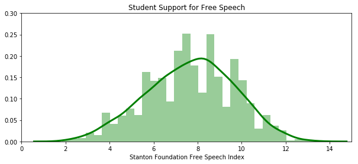

```python
# Plot FSI distribution for all students
sns.set_palette('colorblind')
plt.rcParams["figure.figsize"] = (10, 4)
fig = plt.Figure()

ax = plt.subplot()
sns.distplot(FS_Index, ax=ax, kde_kws={'lw': 3}, color='green')
plt.title("Student Support for Free Speech")
plt.xlabel('Stanton Foundation Free Speech Index')
plt.ylim(0, 0.3)
plt.xlim(0, 15)
plt.show()
```

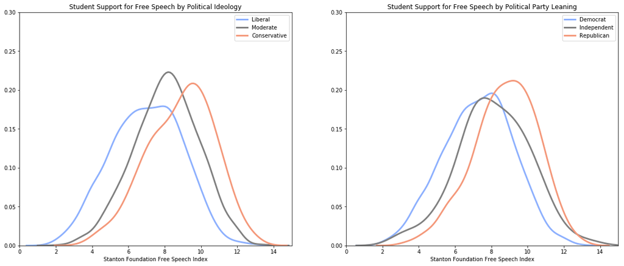

```python
# Plot FSI distribution by rough version of ideology variable and party leaning
sns.set_palette('coolwarm', 3)
plt.rcParams["figure.figsize"] = (20, 8)
fig = plt.Figure()

ax = plt.subplot(1, 2, 1)
sns.distplot(lib_fsi, ax=ax, hist=False, label='Liberal', kde_kws={'lw': 3})
sns.distplot(mod_fsi, ax=ax, hist=False, label='Moderate', kde_kws={'lw': 3, 'color': 'gray'})
sns.distplot(cons_fsi, ax=ax, hist=False, label='Conservative', kde_kws={'lw': 3})
plt.title("Student Support for Free Speech by Political Ideology")
plt.xlabel('Stanton Foundation Free Speech Index')
plt.ylim(0, 0.3)
plt.xlim(0, 15)
plt.legend()

ax = plt.subplot(1, 2, 2)
sns.distplot(dem_fsi, ax=ax, hist=False, label='Democrat', kde_kws={'lw': 3})
sns.distplot(ind_fsi, ax=ax, hist=False, label='Independent', kde_kws={'lw': 3, 'color': 'gray'})
sns.distplot(rep_fsi, ax=ax, hist=False, label='Republican', kde_kws={'lw': 3})
plt.title("Student Support for Free Speech by Political Party Leaning")
plt.xlabel('Stanton Foundation Free Speech Index')
plt.ylim(0, 0.3)
plt.xlim(0, 15)
plt.legend()

plt.show()
```

```python
# t-test to compare means of FSI for students identifying as liberal and students identifying as conservative
ttest_ind(lib_fsi, cons_fsi, equal_var=False)
```

```
Ttest_indResult(statistic=-18.55170678064431, pvalue=1.2111921364414836e-63)
```

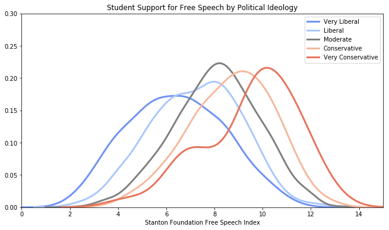

```python
# Plot FSI distribution by finer version of ideology variable
sns.set_palette('coolwarm', 5)
plt.rcParams["figure.figsize"] = (24, 6)
fig = plt.Figure()

ax = plt.subplot(1, 2, 1)
sns.distplot(very_lib_fsi, ax=ax, hist=False, label='Very Liberal', kde_kws={'lw': 3})
sns.distplot(some_lib_fsi, ax=ax, hist=False, label='Liberal', kde_kws={'lw': 3})
sns.distplot(d10_mod_fsi, ax=ax, hist=False, label='Moderate', kde_kws={'lw': 3, 'color': 'gray'})
sns.distplot(some_cons_fsi, ax=ax, hist=False, label='Conservative', kde_kws={'lw': 3})
sns.distplot(very_cons_fsi, ax=ax, hist=False, label='Very Conservative', kde_kws={'lw': 3})
plt.title("Student Support for Free Speech by Political Ideology")
plt.xlabel('Stanton Foundation Free Speech Index')
plt.ylim(0, 0.3)
plt.xlim(0, 15)
plt.legend()
```

```python
# Reset default color scheme to something less political. I like pastel colors.
sns.set_palette('pastel')
```

## Question 1: Can we identify latent variables associated with general positions on free speech?

### Reducing Dimensionality with PCA

PCA is a (relatively) simple approach to dimensionality reduction and latent variable discovery. You can read more about latent variables on Wikipedia: https://en.wikipedia.org/wiki/Latent_variable.

First I create the principal components. I take a look at their explanatory power and their sample distributions. I then take a shot at interpreting the most important principal components as latent variables, *which is an inherently subjective practice*.

**Non-math PCA explanation**: PCA takes an original set of variables and produces a set of new variables we can order from "best" to "worst", where "best" is defined as that which explains the most variation in the original set of variables. When a sample size is sufficiently large, it becomes accurate to say PCA produces the best new variables that can be produced using any similar (i.e. linear) method.

The new variables can sometimes be interpreted to represent real, underlying concepts (latent variables). A classic exmaple is the use of PCA to provide support for the concept of General IQ.

**Math PCA explanation**: Principal Components Analysis(PCA) uses a singular value decomposition to decompose X into UDV. The matrix U is an orthonormal matrix with columns Xv multiplied by the inverse of D, D is a diagonal matrix with the eigenvalues of X'X along the diagonals, and V is a matrix of eigenvectors for X'X that correspond to the eigenvalues in D and the columns of U. Pragmatically and by convention, the matrices are ordered such that the elements of D are arranged from largest to smallest in absolute value. Note that UD=Xv. PCA is a linear transformation producing a matrix W which minimizes the objective function ||X'X-WW'||^2. PCA provides the rank-optimal matrix W such that we can reduce the rank of W and X by some number k and maintain matrices that minimize ||X'X-WW'||^2 where each of X'X and WW' now have rank=rank(X)-k.

The diagonal elements of D are scalars representing the portion of the variance of X explained by the vector UD=Xv. The vectors v, the columns of V, are directions in the original vector space corresponding to the columns of X (as implied by the equivalence of UD and Xv). We can use V to transform the vectors of UD back to the original feature space.

Conceptually, we can view PCA as a rotation of the original feature space axes to produce a new set of axes that point in the directions which maximize the variance explained by each axis. We are effectively creating each new axis one at a time so that each axis maximizes the variance it explains while maintaining orthogonality with all already-created transformed axes.

```python
# Bring in data and separate free speech variables
# I am only using PCA on the free speech variables
df, y, wt, FS_Index = clean_data(raw_data)
fs_vars = df[['FSI_Q4', 'FSI_Q14A', 'FSI_Q14B', 'FSI_Q34A',
       'FSI_Q34B', 'FSI_Q34D', 'FSI_Q34E', 'FSI_Q34F', 'FSI_Q35A', 'FSI_Q35C',
       'FSI_Q35D', 'FSI_Q40B', 'FSI_Q41', 'FSI_Q43']].copy()

demos = df.drop(columns=fs_vars.columns)
```

```python
# Apply PCA to transform data
pca = PCA(random_state=42).fit(fs_vars)
df_pc = pca.transform(fs_vars)
df_pc = pd.DataFrame(df_pc)
```

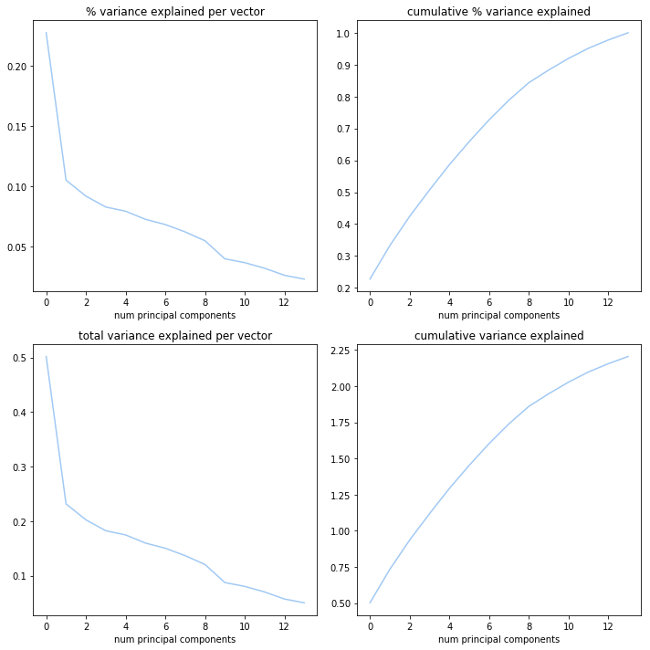

```python
# Investigate the variance accounted for by each principal component

plt.rcParams["figure.figsize"] = (10, 10)
fig = plt.Figure()

# percent of total variance for each vector
plt.subplot(2, 2, 1)
plt.plot(pca.explained_variance_ratio_)
plt.title('% variance explained per vector')
plt.xlabel('num principal components')

# cumulative sum of percent of variance
cumulative_percent_variance = pca.explained_variance_ratio_.cumsum()
plt.subplot(2, 2, 2)
plt.plot(cumulative_percent_variance)
plt.title('cumulative % variance explained')
plt.xlabel('num principal components')

# total variance explained by each vector
plt.subplot(2, 2, 3)
plt.plot(pca.explained_variance_)
plt.title('total variance explained per vector')
plt.xlabel('num principal components')

# cumulative sum of variance
cumulative_variance = pca.explained_variance_.cumsum()
plt.subplot(2, 2, 4)
plt.plot(cumulative_variance)
plt.title('cumulative variance explained')
plt.xlabel('num principal components')

plt.tight_layout()
plt.show()
```

```python
# Print variance explained by principal components
# This is for a rough reference
print('% of variance explained by first 10 PC:\n', pca.explained_variance_ratio_[0:10])
print()
print('cumulative % variance explained by first 10 PC:\n', cumulative_percent_variance[0:10])
print()
print('total variance explained by first 10 PC:\n', pca.explained_variance_[0:10])
print()
print('cumulative variance explained by first 10 PC:\n', cumulative_variance[0:10])
```

```
% of variance explained by first 10 PC:
 [0.22756597 0.10502041 0.09176572 0.08269547 0.07921628 0.07245949
 0.06812769 0.06199227 0.0546149  0.03960684]

cumulative % variance explained by first 10 PC:
 [0.22756597 0.33258638 0.4243521  0.50704757 0.58626385 0.65872333
 0.72685102 0.78884329 0.84345819 0.88306504]

total variance explained by first 10 PC:
 [0.50171119 0.23153689 0.20231448 0.18231743 0.17464691 0.15975032
 0.15020007 0.13667342 0.12040863 0.0873206 ]

cumulative variance explained by first 10 PC:
 [0.50171119 0.73324808 0.93556256 1.11787999 1.2925269  1.45227721
 1.60247728 1.7391507  1.85955932 1.94687992]
```

#### Discussion: The Curse of Dimensionality

Let's take a moment to discuss the curse of dimensionality. As the number of dimensions increases, the density of the sample in the K-dimensional space decreases. With too many features relative to our sample size, a growing proportion of points become distribution outliers. It is possible for a majority of points to be outliers.

The metric I will use to assess the density of the sample in the transformed feature space is based on a hypothetical situation. Suppose our data were uniformly distributed within a unit hypersphere centered at the origin. The sampling density is then proportional to N^(1/p). In other words, to get the same sampling density with 10 inputs as you would have with only 1 input you will need N^10 observations.

This metric is conservative because variables are rarely uniformly distributed. Rather, we very often can often expect substantially more concentrated (i.e. narrower, lower variance) distributions. This is what we observe in our transformed dataset. The distributions of the six "best" (most variance explained) principal components are displayed below.

```python
# Use dimensionality metric to help think about problem
med_dist = [np.power((1-np.power(0.5, 1/df_pc.shape[0])), 1/components) for components in range(1,11)]
print('Using the metric described above, with the following numbers of inputs the median distances from the origin to a point are:\n', med_dist)
```

```
Using the metric described above, with the following numbers of inputs the median distances from the origin to a point are:
 [0.00022994939718556928, 0.015164082470943282, 0.061264763093976035, 0.12314252909106294, 0.18720888431880794, 0.2475171975721607, 0.30215736338758414, 0.35091669822204663, 0.3942184259031035, 0.4326764198784213]
```

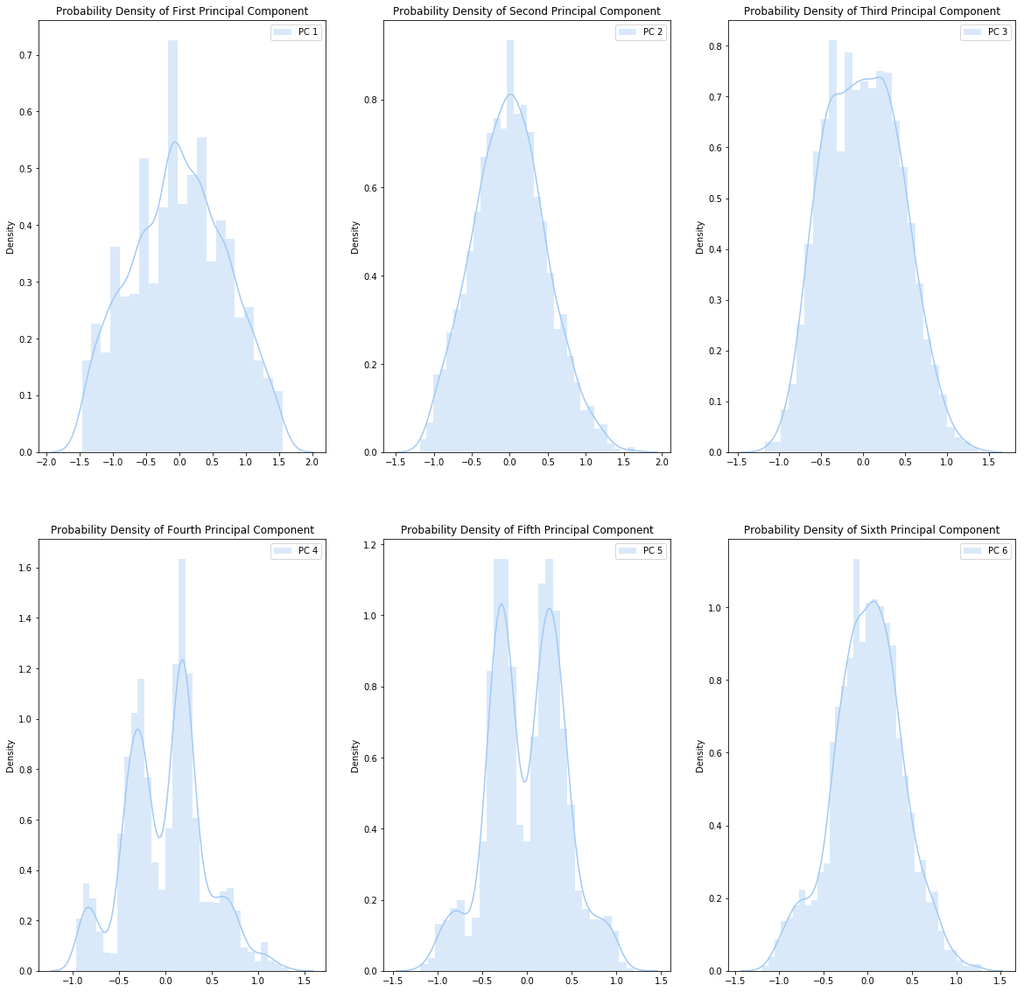

```python
# plot distributions of first six principal components
plt.rcParams["figure.figsize"] = (20, 20)
fig = plt.Figure()

ax = plt.subplot(2, 3, 1)
sns.distplot(df_pc[[0]], ax=ax, label='PC 1')
plt.title('Probability Density of First Principal Component')
plt.ylabel('Density')
plt.legend()

ax = plt.subplot(2, 3, 2)
sns.distplot(df_pc[[1]], ax=ax, label='PC 2')
plt.title('Probability Density of Second Principal Component')
plt.ylabel('Density')
plt.legend()

ax = plt.subplot(2, 3, 3)
sns.distplot(df_pc[[2]], ax=ax, label='PC 3')
plt.title('Probability Density of Third Principal Component')
plt.ylabel('Density')
plt.legend()

ax = plt.subplot(2, 3, 4)
sns.distplot(df_pc[[3]], ax=ax, label='PC 4')
plt.title('Probability Density of Fourth Principal Component')
plt.ylabel('Density')
plt.legend()

ax = plt.subplot(2, 3, 5)
sns.distplot(df_pc[[4]], ax=ax, label='PC 5')
plt.title('Probability Density of Fifth Principal Component')
plt.ylabel('Density')
plt.legend()

ax = plt.subplot(2, 3, 6)
sns.distplot(df_pc[[5]], ax=ax, label='PC 6')
plt.title('Probability Density of Sixth Principal Component')
plt.ylabel('Density')
plt.legend()

plt.show()
```

#### Discussion: How many dimensions?

There is a tradeoff between dimensionality reduction and explanatory power. The more tranformed features used, the more information we retain. However, as we increase dimensions in the transformed feature space we quickly run into the "curse of dimensionality", reducing the likelihood we can find coherent and meaningful clusters.

#### Principal components as latent variables

We can interpet principal components as latent variables if underlying latent variables exist. Such interpretations are somewhat subjective. We risk assuming latent variables exist even when they do not exist in the population.

```python
# takes a list of feature labels from a dataframe fitted to PCA, the fitted PCA object, and eigenvector index k
# returns list of label-weight tuples sorted by weight in descending order
# weights are singular value k * kth eigenvector
# i.e. returns weight of each feature associated with principal direction k
# assumes feature labels are in the same order as the data columns fitted to PCA
def map_pca_weights(labels, pca, k):
    sv = pca.singular_values_[k]
    v = pca.components_[k]
    fw_pairs = zip(labels, v*sv)
    sorted_fw_pairs = sorted(fw_pairs, key=lambda x: abs(x[1]), reverse=True)
    return list(sorted_fw_pairs)

def plot_pca_weight_map(fw_pairs, pc_num):
    # plot feature-weight pairs
    features, weights = zip(*fw_pairs)
    plt.barh(range(len(features)), weights, height=0.7, zorder=2)
    plt.yticks(range(len(features)), features)
    plt.grid(axis='y', linestyle='-.', zorder=1)
    plt.axvline(color='black')
    plt.title(f'Weight of Principal Component {pc_num} in Direction of Each Feature')
    plt.ylabel('Feature', rotation='horizontal', labelpad=30)
    plt.xlabel('Weight')
    plt.show()
```

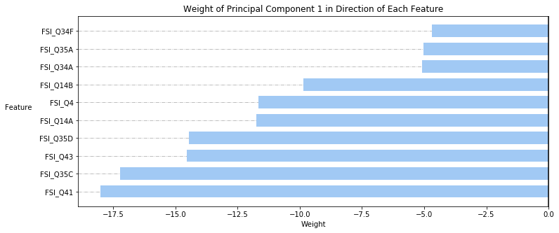

```python
# Map weights for the first principal component to corresponding feature names
# and then print the linked values, sorted by weight.
fw_pairs = map_pca_weights(fs_vars.columns, pca, 0)
plt.rcParams["figure.figsize"] = (12, 5)
plot_pca_weight_map(fw_pairs[0:10], 1)
```

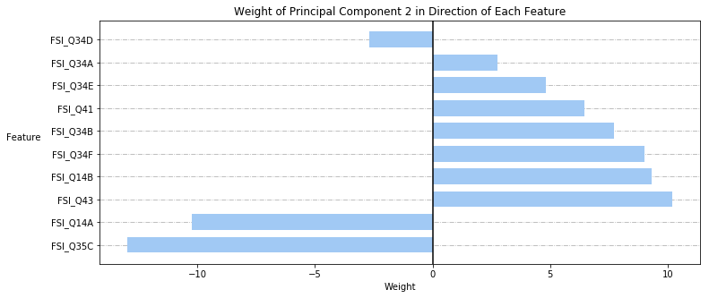

```python
# Map weights for the first principal component to corresponding feature names
# and then print the linked values, sorted by weight.
fw_pairs = map_pca_weights(fs_vars.columns, pca, 1)
plt.rcParams["figure.figsize"] = (12, 5)
plot_pca_weight_map(fw_pairs[0:10], 2)
```

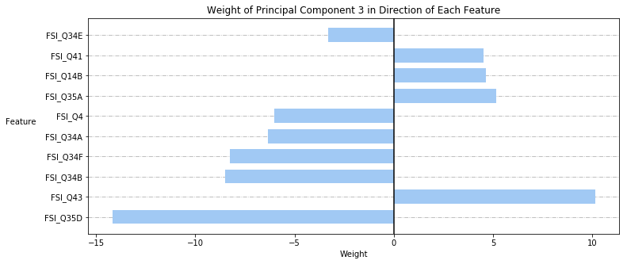

```python
# Map weights for the first principal component to corresponding feature names
# and then print the linked values, sorted by weight.
fw_pairs = map_pca_weights(fs_vars.columns, pca, 2)
plt.rcParams["figure.figsize"] = (12, 5)
plot_pca_weight_map(fw_pairs[0:10], 3)
```

#### Discussion: Latent variables

We can arguably label the first principal component "Political Correctness", which accounts for about 23% of the variance in students' beliefs about free speech.

The "Political Correctness" factor measures preference for protective inclusiveness in lieu of free expression. It is a measure of the extent to which students believe the value of promoting an inclusive society is more important than freedom of express. Students high in this metric favor "instituting speech codes" that could restrict "offensive or biased speech" on campus, removing first amendment protection of hate speech, and "disinviting [sic] speakers because some students are opposed to the invitation".

I found additional evidence for a quality we might label "free speech moderation", the second principal component. Students high in this metric support free speech in general - they believe hate speech should be legally protected, for example - but also want some regulation of speech on campus.

The statistical process also uncovered a third variable I'd like to call "free speech extremism", the third principal component. It measures the extent to which a student expresses blanket support for free speech, including the use of speech to counter unwanted speakers - e.g. by protesting, shouting.

## 2. Can students be clustered by their positions on free speech?

Here I implement clustering methods and juxtapose their performance. I do so first using subsets of the latent variables constructed using PCA, and then instead using the original FSI variables.

I test multiple clustering strategies:

- K-Means
- Guassian Mixture Model
- Density-Based Spatial Clustering of Applications with Noise (DBSCAN)
- Agglomerative

Note that this version of the notebook only retains code for K-Means. This makes the notebook more readable. I kept K-Means because it performed at least as well as the other models, is conceptually simple, and is computationally efficient. You can find results for the other methods in an earlier Git commit.

I use three internal metrics for each model: the objective function, the Silhouette score, and the Calinski-Harabaz score. Both of the latter metrics increase as cluster coherence improves. I print and graph the metric valuations for each hyperparameter combination. I did not use GridSearchCV because it isn't friendly with the Silhouette score as a custom scorer.

The Silhouette score is a ratio measure of differences in distances between points within clusters and points in nearby clusters. For more information on the Silhouette score, see here: https://scikit-learn.org/stable/modules/clustering.html#silhouette-coefficient

The Calinksi-Harabaz score is the ratio of the between-cluster variance to the within-cluster variance in the sample. For more information on the Calinski-Harabaz score, see here: https://scikit-learn.org/stable/modules/clustering.html#calinski-harabaz-index

#### K-Means clustering using latent variable subsets

```python
# Run algorithm, varying hyperparameters

kmeans_metrics = []

num_means = 20
num_components = 10

for t in range(1, num_components+1):

    # Get dataframe with best k components for analysis
    df_T = df_pc.iloc[:,0:t]

    # instantiate collections
    objective = []
    silhouette = []
    calinski_harabaz = []

    # estimate clustering model for t components
    for k in range(2, num_means+1):

        kmeans = KMeans(n_clusters=k, random_state=23953)
        predictions = kmeans.fit_predict(df_T, sample_weight=wt)

        o = -kmeans.score(df_T, sample_weight=wt) / df_T.shape[0]
        objective.append(o)

        s = silhouette_score(df_T, predictions)
        silhouette.append(s)

        ch = calinski_harabaz_score(df_T, predictions)
        calinski_harabaz.append(ch)

    # print and save results for iteration with t components
    print(f'Completed iteration with {t} dimensions')
    kmeans_metrics.append({'objective': objective, 'silhouette': silhouette, 'ch': calinski_harabaz})
```

```
Completed iteration with 1 dimensions
Completed iteration with 2 dimensions
Completed iteration with 3 dimensions
Completed iteration with 4 dimensions
Completed iteration with 5 dimensions
Completed iteration with 6 dimensions
Completed iteration with 7 dimensions
Completed iteration with 8 dimensions
Completed iteration with 9 dimensions
Completed iteration with 10 dimensions
```

```python
# Print results based on hyperparameter variation
for t in range(1, num_components+1):
    dct = kmeans_metrics[t-1]
    for k in range(0, num_means-1):
        obj = dct['objective']
        s = dct['silhouette']
        ch = dct['ch']
        print(f'Components: {t}\t',
              f'Means: {k+2}\t',
              f'MSD: {obj[k]:.2f}\t',
              f'Silhouette: {s[k]:.3f}\t',
              f'Calinski-Harabaz: {ch[k]:.2f}')
    print()
```

```
Components: 1	 Means: 2	 MSD: 0.17	 Silhouette: 0.569	 Calinski-Harabaz: 6255.98
Components: 1	 Means: 3	 MSD: 0.07	 Silhouette: 0.574	 Calinski-Harabaz: 9001.91
Components: 1	 Means: 4	 MSD: 0.04	 Silhouette: 0.541	 Calinski-Harabaz: 10362.63
Components: 1	 Means: 5	 MSD: 0.03	 Silhouette: 0.559	 Calinski-Harabaz: 13262.84
Components: 1	 Means: 6	 MSD: 0.02	 Silhouette: 0.583	 Calinski-Harabaz: 16625.10
Components: 1	 Means: 7	 MSD: 0.01	 Silhouette: 0.585	 Calinski-Harabaz: 18802.32
Components: 1	 Means: 8	 MSD: 0.01	 Silhouette: 0.580	 Calinski-Harabaz: 20763.95
Components: 1	 Means: 9	 MSD: 0.01	 Silhouette: 0.561	 Calinski-Harabaz: 23356.21
Components: 1	 Means: 10	 MSD: 0.01	 Silhouette: 0.555	 Calinski-Harabaz: 25412.19
Components: 1	 Means: 11	 MSD: 0.01	 Silhouette: 0.544	 Calinski-Harabaz: 27016.72
Components: 1	 Means: 12	 MSD: 0.00	 Silhouette: 0.540	 Calinski-Harabaz: 28972.95
Components: 1	 Means: 13	 MSD: 0.00	 Silhouette: 0.532	 Calinski-Harabaz: 30195.97
Components: 1	 Means: 14	 MSD: 0.00	 Silhouette: 0.526	 Calinski-Harabaz: 32351.44
Components: 1	 Means: 15	 MSD: 0.00	 Silhouette: 0.527	 Calinski-Harabaz: 34294.52
Components: 1	 Means: 16	 MSD: 0.00	 Silhouette: 0.535	 Calinski-Harabaz: 36429.80
Components: 1	 Means: 17	 MSD: 0.00	 Silhouette: 0.527	 Calinski-Harabaz: 39249.24
Components: 1	 Means: 18	 MSD: 0.00	 Silhouette: 0.534	 Calinski-Harabaz: 41419.76
Components: 1	 Means: 19	 MSD: 0.00	 Silhouette: 0.523	 Calinski-Harabaz: 42995.35
Components: 1	 Means: 20	 MSD: 0.00	 Silhouette: 0.529	 Calinski-Harabaz: 44806.30

Components: 2	 Means: 2	 MSD: 0.39	 Silhouette: 0.395	 Calinski-Harabaz: 2596.98
Components: 2	 Means: 3	 MSD: 0.27	 Silhouette: 0.361	 Calinski-Harabaz: 2518.12
Components: 2	 Means: 4	 MSD: 0.19	 Silhouette: 0.398	 Calinski-Harabaz: 2860.86
Components: 2	 Means: 5	 MSD: 0.16	 Silhouette: 0.366	 Calinski-Harabaz: 2752.99
Components: 2	 Means: 6	 MSD: 0.14	 Silhouette: 0.352	 Calinski-Harabaz: 2647.07
Components: 2	 Means: 7	 MSD: 0.11	 Silhouette: 0.372	 Calinski-Harabaz: 2693.75
Components: 2	 Means: 8	 MSD: 0.10	 Silhouette: 0.372	 Calinski-Harabaz: 2832.05
Components: 2	 Means: 9	 MSD: 0.09	 Silhouette: 0.359	 Calinski-Harabaz: 2747.21
Components: 2	 Means: 10	 MSD: 0.08	 Silhouette: 0.345	 Calinski-Harabaz: 2729.16
Components: 2	 Means: 11	 MSD: 0.07	 Silhouette: 0.356	 Calinski-Harabaz: 2793.79
Components: 2	 Means: 12	 MSD: 0.06	 Silhouette: 0.358	 Calinski-Harabaz: 2772.99
Components: 2	 Means: 13	 MSD: 0.06	 Silhouette: 0.357	 Calinski-Harabaz: 2796.54
Components: 2	 Means: 14	 MSD: 0.05	 Silhouette: 0.362	 Calinski-Harabaz: 2826.47
Components: 2	 Means: 15	 MSD: 0.05	 Silhouette: 0.361	 Calinski-Harabaz: 2822.11
Components: 2	 Means: 16	 MSD: 0.05	 Silhouette: 0.351	 Calinski-Harabaz: 2752.46
Components: 2	 Means: 17	 MSD: 0.04	 Silhouette: 0.358	 Calinski-Harabaz: 2769.64
Components: 2	 Means: 18	 MSD: 0.04	 Silhouette: 0.353	 Calinski-Harabaz: 2757.03
Components: 2	 Means: 19	 MSD: 0.04	 Silhouette: 0.343	 Calinski-Harabaz: 2763.15
Components: 2	 Means: 20	 MSD: 0.04	 Silhouette: 0.345	 Calinski-Harabaz: 2736.17

```

[output cut: 144 more lines]

```
Components: 10	 Means: 6	 MSD: 1.17	 Silhouette: 0.161	 Calinski-Harabaz: 394.25
Components: 10	 Means: 7	 MSD: 1.12	 Silhouette: 0.156	 Calinski-Harabaz: 362.29
Components: 10	 Means: 8	 MSD: 1.08	 Silhouette: 0.163	 Calinski-Harabaz: 336.88
Components: 10	 Means: 9	 MSD: 1.02	 Silhouette: 0.172	 Calinski-Harabaz: 330.37
Components: 10	 Means: 10	 MSD: 0.99	 Silhouette: 0.172	 Calinski-Harabaz: 307.99
Components: 10	 Means: 11	 MSD: 0.95	 Silhouette: 0.173	 Calinski-Harabaz: 307.92
Components: 10	 Means: 12	 MSD: 0.93	 Silhouette: 0.183	 Calinski-Harabaz: 279.13
Components: 10	 Means: 13	 MSD: 0.90	 Silhouette: 0.180	 Calinski-Harabaz: 280.46
Components: 10	 Means: 14	 MSD: 0.86	 Silhouette: 0.192	 Calinski-Harabaz: 279.80
Components: 10	 Means: 15	 MSD: 0.84	 Silhouette: 0.192	 Calinski-Harabaz: 272.62
Components: 10	 Means: 16	 MSD: 0.83	 Silhouette: 0.189	 Calinski-Harabaz: 262.42
Components: 10	 Means: 17	 MSD: 0.80	 Silhouette: 0.193	 Calinski-Harabaz: 255.49
Components: 10	 Means: 18	 MSD: 0.79	 Silhouette: 0.188	 Calinski-Harabaz: 239.96
Components: 10	 Means: 19	 MSD: 0.76	 Silhouette: 0.212	 Calinski-Harabaz: 246.98
Components: 10	 Means: 20	 MSD: 0.75	 Silhouette: 0.201	 Calinski-Harabaz: 238.27
```

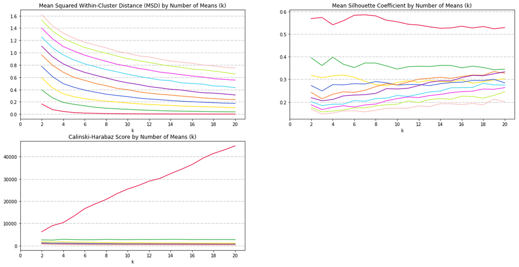

```python
# Visually investigate the change in within-cluster distance across number of clusters.

plt.rcParams["figure.figsize"] = (20, 10)
fig = plt.Figure()
colors = ('#e6194B', '#3cb44b', '#ffe119', '#4363d8', '#f58231', '#911eb4',
          '#42d4f4', '#f032e6', '#bfef45', '#fabebe', '#469990', '#e6beff',
          '#9A6324', '#fffac8', '#800000', '#aaffc3', '#808000', '#ffd8b1')

# MSE
plt.subplot(2, 2, 1)
for t in range(1, num_components+1):
    dct = kmeans_metrics[t-1]
    obj = dct['objective']
    plt.plot(range(2, num_means+1, 1), obj, zorder=2, color=colors[t-1])
plt.title('Mean Squared Within-Cluster Distance (MSD) by Number of Means (k)')
plt.xlabel('k')
plt.xticks(range(0, num_means+1, 2))
plt.grid(axis='y', linestyle='-.', zorder=1)

# Silhouette coefficient
plt.subplot(2, 2, 2)
for t in range(1, num_components+1):
    dct = kmeans_metrics[t-1]
    s = dct['silhouette']
    plt.plot(range(2, num_means+1, 1), s, zorder=2, color=colors[t-1])
plt.title('Mean Silhouette Coefficient by Number of Means (k)')
plt.xlabel('k')
plt.xticks(range(0, num_means+1, 2))
plt.grid(axis='y', linestyle='-.', zorder=1)

# Calinski-Harabaz Score
plt.subplot(2, 2, 3)
for t in range(1, num_components+1):
    dct = kmeans_metrics[t-1]
    ch = dct['ch']
    plt.plot(range(2, num_means+1, 1), ch, zorder=2, color=colors[t-1])
plt.title('Calinski-Harabaz Score by Number of Means (k)')
plt.xlabel('k')
plt.xticks(range(0, num_means+1, 2))
plt.grid(axis='y', linestyle='-.', zorder=1)

plt.show()
```

#### Clustering Discussion: No clear clusters?

```python
# Visualize cluster solution
df_T = df_pc.iloc[:,0:3].copy()
kmeans = KMeans(n_clusters=2, random_state=39576)
cluster = pd.Series(kmeans.fit_predict(df_T, sample_weight=wt))
```

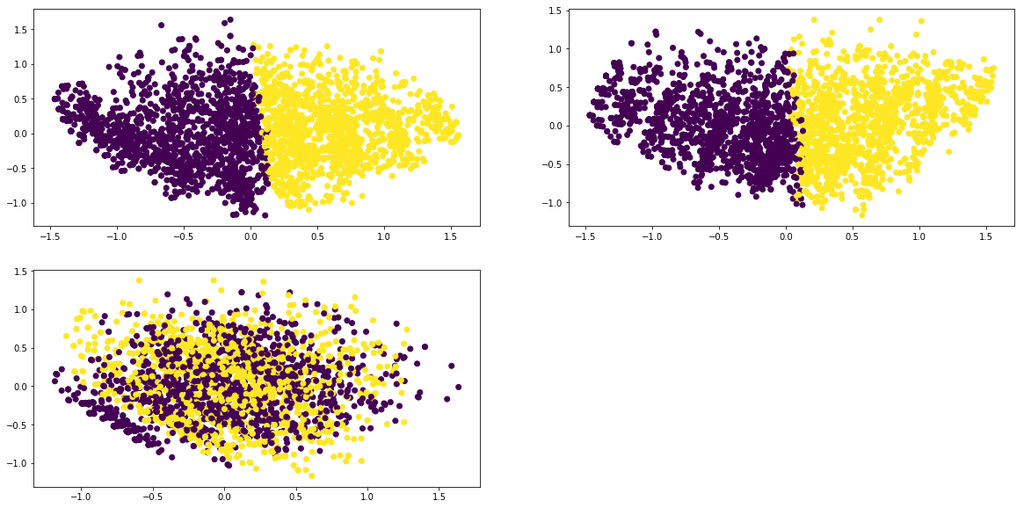

```python
# scatter first three principal components against each other using three two-dimensional graphs
# Student data points are colored by cluster assignment
plt.subplot(2, 2, 1)
plt.scatter(df_T[0],df_T[1], c=cluster)

plt.subplot(2, 2, 2)
plt.scatter(df_T[0],df_T[2], c=cluster)

plt.subplot(2, 2, 3)
plt.scatter(df_T[1],df_T[2], c=cluster)

plt.show()
```

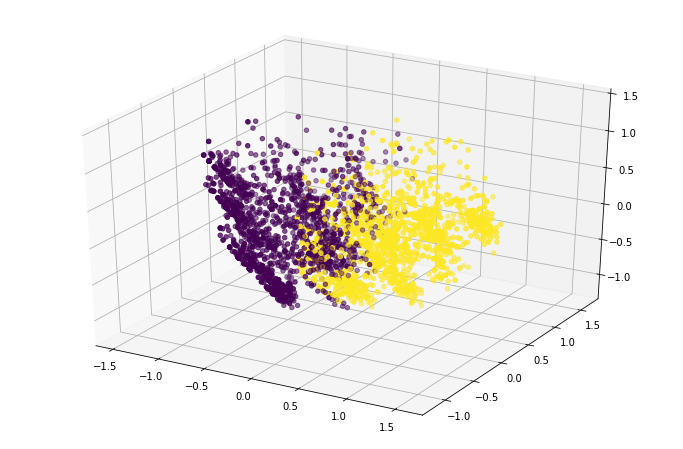

```python
# scatter first three principal components against each other in one three-dimensional graph
# Student data points are colored by cluster assignment
plt.rcParams["figure.figsize"] = (12, 8)

fig = plt.figure()
ax = plt.axes(projection='3d')
ax.scatter3D(df_T[0], df_T[1], df_T[2], c=cluster)
plt.show()
```

#### K-Means clustering with original set of FS variables

```python
num_means = 10
df_T = fs_vars

# instantiate collections
kmeans_metrics = []
objective = []
silhouette = []
calinski_harabaz = []

# estimate clustering model for t components
for k in range(2, num_means+1):

    kmeans = KMeans(n_clusters=k, random_state=23953)
    predictions = kmeans.fit_predict(df_T, sample_weight=wt)

    o = -kmeans.score(df_T, sample_weight=wt) / df_T.shape[0]
    objective.append(o)

    s = silhouette_score(df_T, predictions)
    silhouette.append(s)

    ch = calinski_harabaz_score(df_T, predictions)
    calinski_harabaz.append(ch)

    # print and save results for iteration with t components
    print(f'Completed iteration with {k} means')
kmeans_metrics.append({'objective': objective, 'silhouette': silhouette, 'ch': calinski_harabaz})
```

```
Completed iteration with 2 means
Completed iteration with 3 means
Completed iteration with 4 means
Completed iteration with 5 means
Completed iteration with 6 means
Completed iteration with 7 means
Completed iteration with 8 means
Completed iteration with 9 means
Completed iteration with 10 means
```

```python
dct = kmeans_metrics[0]
for k in range(0, num_means-1):
    obj = dct['objective']
    s = dct['silhouette']
    ch = dct['ch']
    print(f'Means: {k+2}\t',
          f'MSD: {obj[k]:.2f}\t',
          f'Silhouette: {s[k]:.3f}\t',
          f'Calinski-Harabaz: {ch[k]:.2f}')
print()
```

```
Means: 2	 MSD: 1.88	 Silhouette: 0.147	 Calinski-Harabaz: 548.78
Means: 3	 MSD: 1.70	 Silhouette: 0.124	 Calinski-Harabaz: 440.48
Means: 4	 MSD: 1.58	 Silhouette: 0.125	 Calinski-Harabaz: 393.74
Means: 5	 MSD: 1.50	 Silhouette: 0.123	 Calinski-Harabaz: 349.66
Means: 6	 MSD: 1.44	 Silhouette: 0.127	 Calinski-Harabaz: 314.67
Means: 7	 MSD: 1.39	 Silhouette: 0.126	 Calinski-Harabaz: 293.04
Means: 8	 MSD: 1.34	 Silhouette: 0.131	 Calinski-Harabaz: 274.61
Means: 9	 MSD: 1.28	 Silhouette: 0.131	 Calinski-Harabaz: 263.37
Means: 10	 MSD: 1.26	 Silhouette: 0.118	 Calinski-Harabaz: 240.93
```

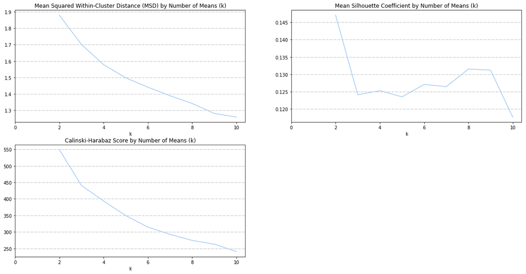

```python
# Investigate the change in within-cluster distance across number of clusters.

plt.rcParams["figure.figsize"] = (20, 10)
fig = plt.Figure()
colors = ('#e6194B', '#3cb44b', '#ffe119', '#4363d8', '#f58231', '#911eb4',
          '#42d4f4', '#f032e6', '#bfef45', '#fabebe', '#469990', '#e6beff',
          '#9A6324', '#fffac8', '#800000', '#aaffc3', '#808000', '#ffd8b1')

obj = dct['objective']
s = dct['silhouette']
ch = dct['ch']

# MSE
plt.subplot(2, 2, 1)
plt.plot(range(2, num_means+1, 1), obj, zorder=2)
plt.title('Mean Squared Within-Cluster Distance (MSD) by Number of Means (k)')
plt.xlabel('k')
plt.xticks(range(0, num_means+1, 2))
plt.grid(axis='y', linestyle='-.', zorder=1)

# Silhouette coefficient
plt.subplot(2, 2, 2)
plt.plot(range(2, num_means+1, 1), s, zorder=2)
plt.title('Mean Silhouette Coefficient by Number of Means (k)')
plt.xlabel('k')
plt.xticks(range(0, num_means+1, 2))
plt.grid(axis='y', linestyle='-.', zorder=1)

# Calinski-Harabaz Score
plt.subplot(2, 2, 3)
plt.plot(range(2, num_means+1, 1), ch, zorder=2)
plt.title('Calinski-Harabaz Score by Number of Means (k)')
plt.xlabel('k')
plt.xticks(range(0, num_means+1, 2))
plt.grid(axis='y', linestyle='-.', zorder=1)

plt.show()
```

## 3. What are the relationships between viable clusters or latent variables and students' political affiliations?

I assess relationships between latent variables and political affiliations using OLS regression. I use OLS because most of the variables are dummy variables or approximately normally distributed. The exception is "ageban", which has five discrete, ordered age values. The model will theoretically fit well for our purposes. Linear probability model parameters tend to be very similar to marginal effects produced by nonlinear models such as logit and probit.

I did not use more "advanced" prediction models because I am not seeking to predict out-of-sample values. I am exploring variable relationships. I want interpretable parameters from a reasonable model. OLS is perfeclty suited for the job at hand.

We might be concerned that I didn't bootstrap the standard errors to account for pre-processing. This is something we may want to keep in mind when looking at p-values. Bootstrapped standard errors would be more accurate and could be slightly larger than those which ignore variability from pre-processing.

```python
# Let's pull in the data again just for code clarity
df, y, wt, FS_Index = clean_data(raw_data)
fs_vars = df[['FSI_Q4', 'FSI_Q14A', 'FSI_Q14B', 'FSI_Q34A',
       'FSI_Q34B', 'FSI_Q34D', 'FSI_Q34E', 'FSI_Q34F', 'FSI_Q35A', 'FSI_Q35C',
       'FSI_Q35D', 'FSI_Q40B', 'FSI_Q41', 'FSI_Q43']].copy()

demos = df.drop(columns=fs_vars.columns)

# Apply PCA to transform data
pca = PCA(random_state=42).fit(fs_vars)
df_pc = pca.transform(fs_vars)
df_pc = pd.DataFrame(df_pc)
```

```python
# Make features matrix with original variables
frames = [demos, fs_vars]
X = pd.concat(frames, axis=1)
# Make feature matrix with transformed variables
frames = [demos, df_pc]
X_trans = pd.concat(frames, axis=1)
# Make features matrix with response variables as covariates (FS_Index will be the new response)
frames = [demos, y]
X_y = pd.concat(frames, axis=1)
```

#### Original FS variables

```python
# y = liberal
response = y['ideolrec_Liberal']
X_vars = sm.add_constant(X)
results_original = sm.WLS(response, X_vars, weights=wt).fit().get_robustcov_results(cov_type='HC2', use_t=True)
print(results_original.summary())
```

```
                            WLS Regression Results
==============================================================================
Dep. Variable:       ideolrec_Liberal   R-squared:                       0.289
Model:                            WLS   Adj. R-squared:                  0.281
Method:                 Least Squares   F-statistic:                     18.53
Date:                Wed, 08 May 2019   Prob (F-statistic):           1.94e-99
Time:                        16:22:19   Log-Likelihood:                -3672.8
No. Observations:                3014   AIC:                             7416.
Df Residuals:                    2979   BIC:                             7626.
Df Model:                          34
Covariance Type:                  HC2
======================================================================================
                         coef    std err          t      P>|t|      [0.025      0.975]
--------------------------------------------------------------------------------------
const                  0.7607      0.109      6.954      0.000       0.546       0.975
ageban                -0.0118      0.012     -1.003      0.316      -0.035       0.011
Race_Black            -0.0651      0.065     -1.006      0.315      -0.192       0.062
Race_Hispanic          0.0158      0.055      0.290      0.772      -0.091       0.123
Race_Asian             0.0314      0.062      0.503      0.615      -0.091       0.154
Race_Other            -0.0952      0.072     -1.317      0.188      -0.237       0.047
Region_East            0.1101      0.051      2.179      0.029       0.011       0.209
Region_MidWest         0.0120      0.038      0.316      0.752      -0.063       0.087
Region_South           0.1234      0.061      2.012      0.044       0.003       0.244
Institution_Public    -0.0484      0.035     -1.370      0.171      -0.118       0.021
genderban_1.0          0.0035      0.036      0.096      0.923      -0.067       0.074
genderban_2.0          0.4529      0.280      1.620      0.105      -0.095       1.001
relban_1.0            -0.0053      0.047     -0.114      0.909      -0.097       0.087
relban_2.0             0.2730      0.092      2.953      0.003       0.092       0.454
relban_3.0            -0.2220      0.050     -4.404      0.000      -0.321      -0.123
relban_4.0             0.2262      0.040      5.607      0.000       0.147       0.305
relban_5.0            -0.0018      0.066     -0.027      0.979      -0.132       0.129
soc_classrec_1.0       0.0579      0.043      1.359      0.174      -0.026       0.141
soc_classrec_2.0       0.0922      0.046      2.014      0.044       0.002       0.182
arearec_1.0            0.0189      0.041      0.457      0.648      -0.062       0.100
arearec_2.0           -0.0420      0.042     -0.991      0.322      -0.125       0.041
FSI_Q4                -0.0908      0.042     -2.171      0.030      -0.173      -0.009
FSI_Q14A               0.0115      0.037      0.315      0.753      -0.060       0.083
FSI_Q14B              -0.0091      0.039     -0.230      0.818      -0.086       0.068
FSI_Q34A              -0.0471      0.063     -0.748      0.454      -0.171       0.076
FSI_Q34B              -0.1557      0.055     -2.816      0.005      -0.264      -0.047
FSI_Q34D               0.0874      0.054      1.630      0.103      -0.018       0.193
FSI_Q34E              -0.0923      0.056     -1.661      0.097      -0.201       0.017
FSI_Q34F              -0.1556      0.051     -3.054      0.002      -0.256      -0.056
FSI_Q35A               0.0059      0.043      0.137      0.891      -0.078       0.090
FSI_Q35C              -0.0079      0.036     -0.219      0.827      -0.079       0.063
FSI_Q35D              -0.0658      0.041     -1.610      0.108      -0.146       0.014
FSI_Q40B              -0.0180      0.067     -0.269      0.788      -0.150       0.114
FSI_Q41               -0.2372      0.039     -6.157      0.000      -0.313      -0.162
FSI_Q43               -0.1075      0.041     -2.641      0.008      -0.187      -0.028
==============================================================================
Omnibus:                      356.309   Durbin-Watson:                   1.973
Prob(Omnibus):                  0.000   Jarque-Bera (JB):             3596.960
Skew:                           0.033   Prob(JB):                         0.00
Kurtosis:                       8.351   Cond. No.                         459.
==============================================================================

Warnings:
[1] Standard Errors are heteroscedasticity robust (HC2)
```

#### Transformed FS variables

```python
# y = very liberal
response = y['D10_Very liberal']
X_vars = pd.DataFrame(StandardScaler().fit_transform(X_trans), columns=X_trans.columns)
X_vars = sm.add_constant(X_vars)
results_trans = sm.WLS(response, X_vars, weights=wt).fit().get_robustcov_results(cov_type='HC2', use_t=True)
print(results_trans.summary())
```

```
                            WLS Regression Results
==============================================================================
Dep. Variable:       D10_Very liberal   R-squared:                       0.190
Model:                            WLS   Adj. R-squared:                  0.181
Method:                 Least Squares   F-statistic:                     5.877
Date:                Wed, 08 May 2019   Prob (F-statistic):           2.17e-24
Time:                        16:22:23   Log-Likelihood:                -2977.5
No. Observations:                3014   AIC:                             6025.
Df Residuals:                    2979   BIC:                             6235.
Df Model:                          34
Covariance Type:                  HC2
======================================================================================
                         coef    std err          t      P>|t|      [0.025      0.975]
--------------------------------------------------------------------------------------
const                  0.1574      0.012     13.344      0.000       0.134       0.181
ageban                -0.0058      0.014     -0.403      0.687      -0.034       0.022
Race_Black            -0.0003      0.014     -0.019      0.985      -0.028       0.028
Race_Hispanic          0.0021      0.015      0.137      0.891      -0.028       0.032
Race_Asian             0.0075      0.019      0.385      0.701      -0.031       0.046
Race_Other             0.0058      0.017      0.336      0.737      -0.028       0.039
Region_East            0.0039      0.013      0.304      0.761      -0.021       0.029
Region_MidWest         0.0021      0.014      0.145      0.885      -0.026       0.030
Region_South           0.0152      0.018      0.823      0.411      -0.021       0.051
Institution_Public    -0.0140      0.013     -1.036      0.300      -0.040       0.012
genderban_1.0          0.0165      0.014      1.150      0.250      -0.012       0.045
genderban_2.0          0.0051      0.009      0.570      0.569      -0.012       0.023
relban_1.0            -0.0179      0.012     -1.541      0.123      -0.041       0.005
relban_2.0             0.0435      0.020      2.138      0.033       0.004       0.083
relban_3.0            -0.0057      0.005     -1.140      0.254      -0.015       0.004
relban_4.0             0.0561      0.017      3.353      0.001       0.023       0.089
relban_5.0            -0.0066      0.014     -0.459      0.646      -0.035       0.022
soc_classrec_1.0      -0.0116      0.017     -0.662      0.508      -0.046       0.023
soc_classrec_2.0      -0.0095      0.018     -0.533      0.594      -0.044       0.025
arearec_1.0            0.0008      0.016      0.052      0.959      -0.031       0.033
arearec_2.0            0.0278      0.015      1.808      0.071      -0.002       0.058
0                      0.0858      0.015      5.562      0.000       0.056       0.116
1                     -0.0452      0.013     -3.558      0.000      -0.070      -0.020
2                      0.0518      0.014      3.829      0.000       0.025       0.078
3                     -0.0051      0.014     -0.366      0.714      -0.033       0.022
4                     -0.0050      0.014     -0.369      0.712      -0.032       0.022
5                      0.0013      0.013      0.100      0.920      -0.024       0.027
6                      0.0017      0.014      0.126      0.899      -0.025       0.029
7                      0.0406      0.013      3.030      0.002       0.014       0.067
8                      0.0084      0.013      0.632      0.527      -0.018       0.034
9                     -0.0100      0.013     -0.776      0.438      -0.035       0.015
10                    -0.0060      0.011     -0.539      0.590      -0.028       0.016
11                     0.0038      0.013      0.282      0.778      -0.023       0.030
12                     0.0228      0.014      1.670      0.095      -0.004       0.050
13                    -0.0101      0.013     -0.762      0.446      -0.036       0.016
==============================================================================
Omnibus:                     1791.211   Durbin-Watson:                   1.984
Prob(Omnibus):                  0.000   Jarque-Bera (JB):            25560.476
Skew:                           2.557   Prob(JB):                         0.00
Kurtosis:                      16.318   Cond. No.                         7.34
==============================================================================

Warnings:
[1] Standard Errors are heteroscedasticity robust (HC2)
```

```python
# y = liberal
response = y['D10_Liberal']
X_vars = pd.DataFrame(StandardScaler().fit_transform(X_trans), columns=X_trans.columns)
X_vars = sm.add_constant(X_vars)
results_trans = sm.WLS(response, X_vars, weights=wt).fit().get_robustcov_results(cov_type='HC2', use_t=True)
print(results_trans.summary())
```

```
                            WLS Regression Results
==============================================================================
Dep. Variable:            D10_Liberal   R-squared:                       0.104
Model:                            WLS   Adj. R-squared:                  0.093
Method:                 Least Squares   F-statistic:                     5.365
Date:                Wed, 08 May 2019   Prob (F-statistic):           2.02e-21
Time:                        16:22:24   Log-Likelihood:                -3807.2
No. Observations:                3014   AIC:                             7684.
Df Residuals:                    2979   BIC:                             7895.
Df Model:                          34
Covariance Type:                  HC2
======================================================================================
                         coef    std err          t      P>|t|      [0.025      0.975]
--------------------------------------------------------------------------------------
const                  0.3246      0.017     19.521      0.000       0.292       0.357
ageban                -0.0108      0.017     -0.621      0.535      -0.045       0.023
Race_Black            -0.0206      0.020     -1.008      0.313      -0.061       0.019
Race_Hispanic          0.0037      0.021      0.176      0.860      -0.038       0.045
Race_Asian             0.0028      0.022      0.126      0.899      -0.041       0.046
Race_Other            -0.0174      0.017     -1.000      0.317      -0.052       0.017
Region_East            0.0337      0.017      1.946      0.052      -0.000       0.068
Region_MidWest         0.0038      0.020      0.192      0.848      -0.035       0.043
Region_South           0.0379      0.027      1.385      0.166      -0.016       0.092
Institution_Public    -0.0076      0.017     -0.445      0.657      -0.041       0.026
genderban_1.0         -0.0148      0.019     -0.791      0.429      -0.051       0.022
genderban_2.0          0.0066      0.016      0.415      0.678      -0.024       0.038
relban_1.0             0.0158      0.019      0.849      0.396      -0.021       0.052
relban_2.0             0.0112      0.020      0.544      0.586      -0.029       0.051
relban_3.0            -0.0291      0.008     -3.803      0.000      -0.044      -0.014
relban_4.0             0.0534      0.021      2.603      0.009       0.013       0.094
relban_5.0             0.0062      0.018      0.347      0.728      -0.029       0.041
soc_classrec_1.0       0.0403      0.021      1.932      0.054      -0.001       0.081
soc_classrec_2.0       0.0501      0.021      2.432      0.015       0.010       0.090
arearec_1.0            0.0085      0.022      0.383      0.702      -0.035       0.052
arearec_2.0           -0.0466      0.020     -2.281      0.023      -0.087      -0.007
0                      0.0752      0.018      4.104      0.000       0.039       0.111
1                     -0.0597      0.017     -3.575      0.000      -0.092      -0.027
2                     -0.0066      0.017     -0.393      0.694      -0.040       0.026
3                      0.0340      0.017      2.023      0.043       0.001       0.067
4                      0.0384      0.016      2.400      0.016       0.007       0.070
5                     -0.0206      0.018     -1.173      0.241      -0.055       0.014
6                     -0.0029      0.018     -0.160      0.873      -0.038       0.032
7                      0.0009      0.017      0.055      0.956      -0.032       0.034
8                     -0.0151      0.017     -0.886      0.376      -0.049       0.018
9                     -0.0197      0.016     -1.228      0.219      -0.051       0.012
10                    -0.0062      0.016     -0.377      0.706      -0.038       0.026
11                    -0.0059      0.015     -0.379      0.704      -0.036       0.024
12                    -0.0254      0.016     -1.559      0.119      -0.057       0.007
13                     0.0134      0.017      0.797      0.426      -0.020       0.046
==============================================================================
Omnibus:                      711.396   Durbin-Watson:                   2.039
Prob(Omnibus):                  0.000   Jarque-Bera (JB):             2744.618
Skew:                           1.118   Prob(JB):                         0.00
Kurtosis:                       7.105   Cond. No.                         7.34
==============================================================================

Warnings:
[1] Standard Errors are heteroscedasticity robust (HC2)
```

```python
# y = moderate
response = y['D10_Moderate']
X_vars = pd.DataFrame(StandardScaler().fit_transform(X_trans), columns=X_trans.columns)
X_vars = sm.add_constant(X_vars)
results_trans = sm.WLS(response, X_vars, weights=wt).fit().get_robustcov_results(cov_type='HC2', use_t=True)
print(results_trans.summary())
```

```
                            WLS Regression Results
==============================================================================
Dep. Variable:           D10_Moderate   R-squared:                       0.099
Model:                            WLS   Adj. R-squared:                  0.089
Method:                 Least Squares   F-statistic:                     3.841
Date:                Wed, 08 May 2019   Prob (F-statistic):           6.68e-13
Time:                        16:22:24   Log-Likelihood:                -3904.8
No. Observations:                3014   AIC:                             7880.
Df Residuals:                    2979   BIC:                             8090.
Df Model:                          34
Covariance Type:                  HC2
======================================================================================
                         coef    std err          t      P>|t|      [0.025      0.975]
--------------------------------------------------------------------------------------
const                  0.3565      0.016     22.072      0.000       0.325       0.388
ageban                 0.0181      0.017      1.036      0.300      -0.016       0.052
Race_Black             0.0468      0.021      2.199      0.028       0.005       0.089
Race_Hispanic          0.0080      0.021      0.377      0.706      -0.033       0.049
Race_Asian            -0.0085      0.022     -0.383      0.702      -0.052       0.035
Race_Other             0.0024      0.015      0.160      0.873      -0.027       0.032
Region_East           -0.0411      0.018     -2.281      0.023      -0.076      -0.006
Region_MidWest        -0.0363      0.021     -1.737      0.082      -0.077       0.005
Region_South          -0.0652      0.027     -2.384      0.017      -0.119      -0.012
Institution_Public    -0.0012      0.017     -0.069      0.945      -0.035       0.033
genderban_1.0         -0.0062      0.019     -0.325      0.745      -0.044       0.031
genderban_2.0         -0.0077      0.004     -1.738      0.082      -0.016       0.001
relban_1.0             0.0237      0.022      1.098      0.272      -0.019       0.066
relban_2.0            -0.0223      0.018     -1.247      0.212      -0.057       0.013
relban_3.0             0.0300      0.015      1.992      0.046       0.000       0.059
relban_4.0            -0.0317      0.022     -1.468      0.142      -0.074       0.011
relban_5.0             0.0357      0.019      1.916      0.055      -0.001       0.072
soc_classrec_1.0      -0.0188      0.023     -0.833      0.405      -0.063       0.025
soc_classrec_2.0      -0.0423      0.022     -1.944      0.052      -0.085       0.000
arearec_1.0            0.0089      0.021      0.416      0.678      -0.033       0.051
arearec_2.0            0.0284      0.021      1.356      0.175      -0.013       0.069
0                     -0.0572      0.017     -3.309      0.001      -0.091      -0.023
1                      0.0477      0.018      2.622      0.009       0.012       0.083
2                     -0.0428      0.017     -2.520      0.012      -0.076      -0.010
3                     -0.0125      0.018     -0.706      0.480      -0.047       0.022
4                     -0.0249      0.017     -1.447      0.148      -0.059       0.009
5                     -0.0002      0.020     -0.010      0.992      -0.038       0.038
6                     -0.0218      0.018     -1.228      0.219      -0.056       0.013
7                     -0.0281      0.017     -1.629      0.103      -0.062       0.006
8                     -0.0194      0.017     -1.150      0.250      -0.053       0.014
9                      0.0276      0.018      1.506      0.132      -0.008       0.064
10                     0.0353      0.017      2.016      0.044       0.001       0.070
11                    -0.0134      0.018     -0.748      0.455      -0.049       0.022
12                     0.0099      0.017      0.569      0.569      -0.024       0.044
13                    -0.0216      0.017     -1.277      0.202      -0.055       0.012
==============================================================================
Omnibus:                      540.299   Durbin-Watson:                   1.939
Prob(Omnibus):                  0.000   Jarque-Bera (JB):             1924.301
Skew:                           0.869   Prob(JB):                         0.00
Kurtosis:                       6.508   Cond. No.                         7.34
==============================================================================

Warnings:
[1] Standard Errors are heteroscedasticity robust (HC2)
```

```python
# y = conservative
response = y['D10_Conservative']
X_vars = pd.DataFrame(StandardScaler().fit_transform(X_trans), columns=X_trans.columns)
X_vars = sm.add_constant(X_vars)
results_trans = sm.WLS(response, X_vars, weights=wt).fit().get_robustcov_results(cov_type='HC2', use_t=True)
print(results_trans.summary())
```

```
                            WLS Regression Results
==============================================================================
Dep. Variable:       D10_Conservative   R-squared:                       0.149
Model:                            WLS   Adj. R-squared:                  0.139
Method:                 Least Squares   F-statistic:                     3.846
Date:                Wed, 08 May 2019   Prob (F-statistic):           6.28e-13
Time:                        16:22:24   Log-Likelihood:                -2667.9
No. Observations:                3014   AIC:                             5406.
Df Residuals:                    2979   BIC:                             5616.
Df Model:                          34
Covariance Type:                  HC2
======================================================================================
                         coef    std err          t      P>|t|      [0.025      0.975]
--------------------------------------------------------------------------------------
const                  0.1193      0.011     11.218      0.000       0.098       0.140
ageban                 0.0038      0.012      0.326      0.745      -0.019       0.026
Race_Black            -0.0118      0.013     -0.877      0.380      -0.038       0.015
Race_Hispanic         -0.0136      0.013     -1.035      0.301      -0.039       0.012
Race_Asian             0.0026      0.013      0.206      0.836      -0.022       0.027
Race_Other            -0.0034      0.010     -0.358      0.720      -0.022       0.015
Region_East           -0.0112      0.010     -1.103      0.270      -0.031       0.009
Region_MidWest         0.0129      0.013      0.958      0.338      -0.013       0.039
Region_South          -0.0026      0.017     -0.146      0.884      -0.037       0.032
Institution_Public     0.0094      0.012      0.808      0.419      -0.013       0.032
genderban_1.0      -7.974e-05      0.012     -0.007      0.995      -0.024       0.024
genderban_2.0         -0.0030      0.003     -0.987      0.324      -0.009       0.003
relban_1.0            -0.0142      0.017     -0.850      0.396      -0.047       0.019
relban_2.0            -0.0234      0.011     -2.063      0.039      -0.046      -0.001
relban_3.0             0.0070      0.014      0.510      0.610      -0.020       0.034
relban_4.0            -0.0652      0.016     -4.201      0.000      -0.096      -0.035
relban_5.0            -0.0275      0.011     -2.597      0.009      -0.048      -0.007
soc_classrec_1.0      -0.0141      0.015     -0.957      0.339      -0.043       0.015
soc_classrec_2.0      -0.0139      0.015     -0.939      0.348      -0.043       0.015
arearec_1.0           -0.0142      0.014     -0.999      0.318      -0.042       0.014
arearec_2.0            0.0046      0.015      0.319      0.750      -0.024       0.033
0                     -0.0690      0.013     -5.267      0.000      -0.095      -0.043
1                      0.0339      0.011      3.207      0.001       0.013       0.055
2                     -0.0108      0.012     -0.874      0.382      -0.035       0.013
3                     -0.0254      0.010     -2.536      0.011      -0.045      -0.006
4                     -0.0179      0.012     -1.544      0.123      -0.041       0.005
5                      0.0094      0.012      0.786      0.432      -0.014       0.033
6                      0.0174      0.009      1.966      0.049    4.95e-05       0.035
7                     -0.0214      0.011     -1.945      0.052      -0.043       0.000
8                      0.0178      0.011      1.572      0.116      -0.004       0.040
9                      0.0070      0.011      0.641      0.522      -0.014       0.028
10                    -0.0197      0.011     -1.765      0.078      -0.042       0.002
11                     0.0078      0.011      0.688      0.491      -0.014       0.030
12                    -0.0031      0.011     -0.287      0.774      -0.024       0.018
13                     0.0070      0.011      0.669      0.503      -0.014       0.028
==============================================================================
Omnibus:                     2229.501   Durbin-Watson:                   2.027
Prob(Omnibus):                  0.000   Jarque-Bera (JB):            46147.457
Skew:                           3.339   Prob(JB):                         0.00
Kurtosis:                      20.968   Cond. No.                         7.34
==============================================================================

Warnings:
[1] Standard Errors are heteroscedasticity robust (HC2)
```

```python
# y = very conservative
response = y['D10_Very conservative']
X_vars = pd.DataFrame(StandardScaler().fit_transform(X_trans), columns=X_trans.columns)
X_vars = sm.add_constant(X_vars)
results_trans = sm.WLS(response, X_vars, weights=wt).fit().get_robustcov_results(cov_type='HC2', use_t=True)
print(results_trans.summary())
```

```
                              WLS Regression Results
=================================================================================
Dep. Variable:     D10_Very conservative   R-squared:                       0.108
Model:                               WLS   Adj. R-squared:                  0.098
Method:                    Least Squares   F-statistic:                     1.199
Date:                   Wed, 08 May 2019   Prob (F-statistic):              0.199
Time:                           16:22:24   Log-Likelihood:                -928.90
No. Observations:                   3014   AIC:                             1928.
Df Residuals:                       2979   BIC:                             2138.
Df Model:                             34
Covariance Type:                     HC2
======================================================================================
                         coef    std err          t      P>|t|      [0.025      0.975]
--------------------------------------------------------------------------------------
const                  0.0352      0.007      5.354      0.000       0.022       0.048
ageban                -0.0085      0.008     -1.059      0.290      -0.024       0.007
Race_Black            -0.0134      0.006     -2.305      0.021      -0.025      -0.002
Race_Hispanic          0.0026      0.011      0.235      0.814      -0.019       0.024
Race_Asian            -0.0056      0.004     -1.456      0.145      -0.013       0.002
Race_Other            -0.0048      0.004     -1.204      0.229      -0.013       0.003
Region_East            0.0163      0.008      2.168      0.030       0.002       0.031
Region_MidWest         0.0191      0.010      1.824      0.068      -0.001       0.040
Region_South           0.0156      0.010      1.528      0.127      -0.004       0.036
Institution_Public     0.0117      0.008      1.492      0.136      -0.004       0.027
genderban_1.0          0.0021      0.006      0.337      0.736      -0.010       0.014
genderban_2.0         -0.0012      0.001     -1.369      0.171      -0.003       0.001
relban_1.0            -0.0088      0.010     -0.873      0.383      -0.028       0.011
relban_2.0            -0.0091      0.004     -2.098      0.036      -0.018      -0.001
relban_3.0             0.0004      0.004      0.084      0.933      -0.008       0.009
relban_4.0            -0.0192      0.010     -1.978      0.048      -0.038      -0.000
relban_5.0            -0.0067      0.005     -1.431      0.152      -0.016       0.002
soc_classrec_1.0       0.0018      0.007      0.253      0.801      -0.012       0.016
soc_classrec_2.0       0.0129      0.009      1.448      0.148      -0.005       0.030
arearec_1.0           -0.0045      0.009     -0.514      0.607      -0.021       0.013
arearec_2.0           -0.0145      0.009     -1.566      0.118      -0.033       0.004
0                     -0.0344      0.009     -3.708      0.000      -0.053      -0.016
1                      0.0183      0.006      3.284      0.001       0.007       0.029
2                      0.0115      0.008      1.497      0.134      -0.004       0.027
3                      0.0075      0.006      1.233      0.218      -0.004       0.019
4                      0.0092      0.006      1.623      0.105      -0.002       0.020
5                      0.0111      0.005      2.190      0.029       0.001       0.021
6                      0.0046      0.006      0.726      0.468      -0.008       0.017
7                      0.0097      0.007      1.479      0.139      -0.003       0.023
8                      0.0060      0.007      0.799      0.424      -0.009       0.021
9                     -0.0076      0.007     -1.145      0.252      -0.021       0.005
10                    -0.0017      0.007     -0.246      0.806      -0.015       0.012
11                     0.0119      0.008      1.546      0.122      -0.003       0.027
12                    -0.0057      0.006     -1.006      0.314      -0.017       0.005
13                     0.0058      0.005      1.190      0.234      -0.004       0.015
==============================================================================
Omnibus:                     4327.889   Durbin-Watson:                   2.013
Prob(Omnibus):                  0.000   Jarque-Bera (JB):          1156852.075
Skew:                           8.571   Prob(JB):                         0.00
Kurtosis:                      97.435   Cond. No.                         7.34
==============================================================================

Warnings:
[1] Standard Errors are heteroscedasticity robust (HC2)
```

#### Predicting FSI

```python
# predicting FSI with ideology
X_vars = X_y.drop(columns=['ideolrec_Moderate', 'PARTYL_Independent/no lean',
                             'PARTYL_Democrat/lean Democrat', 'PARTYL_Republican/lean Republican',
                             'ideolrec_Liberal', 'ideolrec_Conservative', 'D10_Moderate'])
X_vars = sm.add_constant(X_vars)
results_fsi = sm.WLS(endog=FS_Index, exog=X_vars, weights=wt).fit().get_robustcov_results(cov_type='HC2', use_t=True)
print(results_fsi.summary())
```

```
                            WLS Regression Results
==============================================================================
Dep. Variable:               FS_Index   R-squared:                       0.228
Model:                            WLS   Adj. R-squared:                  0.222
Method:                 Least Squares   F-statistic:                     11.24
Date:                Wed, 08 May 2019   Prob (F-statistic):           2.41e-41
Time:                        16:22:25   Log-Likelihood:                -7870.0
No. Observations:                3014   AIC:                         1.579e+04
Df Residuals:                    2989   BIC:                         1.594e+04
Df Model:                          24
Covariance Type:                  HC2
=========================================================================================
                            coef    std err          t      P>|t|      [0.025      0.975]
-----------------------------------------------------------------------------------------
const                     8.8455      0.313     28.282      0.000       8.232       9.459
ageban                   -0.0836      0.046     -1.802      0.072      -0.175       0.007
Race_Black               -0.4451      0.187     -2.384      0.017      -0.811      -0.079
Race_Hispanic            -0.2000      0.220     -0.907      0.364      -0.632       0.232
Race_Asian               -0.3121      0.255     -1.225      0.221      -0.812       0.188
Race_Other               -0.1007      0.436     -0.231      0.817      -0.956       0.755
Region_East              -0.0109      0.200     -0.055      0.956      -0.403       0.381
Region_MidWest           -0.1651      0.151     -1.096      0.273      -0.460       0.130
Region_South              0.0169      0.222      0.076      0.939      -0.418       0.452
Institution_Public        0.1653      0.141      1.174      0.241      -0.111       0.442
genderban_1.0            -0.8220      0.135     -6.101      0.000      -1.086      -0.558
genderban_2.0            -0.4681      0.860     -0.544      0.586      -2.155       1.219
relban_1.0               -0.0084      0.184     -0.046      0.963      -0.369       0.352
relban_2.0               -0.1412      0.376     -0.376      0.707      -0.878       0.595
relban_3.0               -0.1133      0.258     -0.439      0.660      -0.619       0.392
relban_4.0               -0.1312      0.162     -0.811      0.417      -0.448       0.186
relban_5.0               -0.3768      0.267     -1.412      0.158      -0.900       0.146
soc_classrec_1.0         -0.0762      0.162     -0.472      0.637      -0.393       0.241
soc_classrec_2.0         -0.0692      0.180     -0.385      0.700      -0.421       0.283
arearec_1.0              -0.0307      0.149     -0.206      0.836      -0.322       0.261
arearec_2.0               0.0617      0.163      0.379      0.705      -0.257       0.381
D10_Very conservative     1.3791      0.283      4.870      0.000       0.824       1.934
D10_Conservative          0.7333      0.177      4.147      0.000       0.387       1.080
D10_Liberal              -0.6152      0.158     -3.882      0.000      -0.926      -0.305
D10_Very liberal         -1.3339      0.221     -6.043      0.000      -1.767      -0.901
==============================================================================
Omnibus:                      488.833   Durbin-Watson:                   2.005
Prob(Omnibus):                  0.000   Jarque-Bera (JB):             8676.801
Skew:                          -0.133   Prob(JB):                         0.00
Kurtosis:                      11.308   Cond. No.                         377.
==============================================================================

Warnings:
[1] Standard Errors are heteroscedasticity robust (HC2)
```

```python
# predicting FSI with party
X_vars = X_y.drop(columns=['ideolrec_Moderate', 'PARTYL_Independent/no lean',
                              'ideolrec_Liberal', 'ideolrec_Conservative',
                              'D10_Very conservative', 'D10_Conservative',
                              'D10_Moderate', 'D10_Liberal', 'D10_Very liberal'])
X_vars = sm.add_constant(X_vars)
results_fsi = sm.WLS(endog=FS_Index, exog=X_vars, weights=wt).fit().get_robustcov_results(cov_type='HC2', use_t=True)
print(results_fsi.summary())
```

```
                            WLS Regression Results
==============================================================================
Dep. Variable:               FS_Index   R-squared:                       0.184
Model:                            WLS   Adj. R-squared:                  0.178
Method:                 Least Squares   F-statistic:                     9.135
Date:                Wed, 08 May 2019   Prob (F-statistic):           1.01e-29
Time:                        16:22:25   Log-Likelihood:                -7954.5
No. Observations:                3014   AIC:                         1.595e+04
Df Residuals:                    2991   BIC:                         1.609e+04
Df Model:                          22
Covariance Type:                  HC2
=====================================================================================================
                                        coef    std err          t      P>|t|      [0.025      0.975]
-----------------------------------------------------------------------------------------------------
const                                 9.4521      0.449     21.037      0.000       8.571      10.333
ageban                               -0.0924      0.047     -1.961      0.050      -0.185   -2.36e-05
Race_Black                           -0.3461      0.201     -1.724      0.085      -0.740       0.048
Race_Hispanic                        -0.1268      0.226     -0.560      0.576      -0.571       0.317
Race_Asian                           -0.4176      0.259     -1.613      0.107      -0.925       0.090
Race_Other                           -0.0982      0.484     -0.203      0.839      -1.047       0.850
Region_East                          -0.0294      0.203     -0.145      0.885      -0.428       0.369
Region_MidWest                       -0.2192      0.157     -1.395      0.163      -0.527       0.089
Region_South                         -0.0292      0.223     -0.131      0.896      -0.467       0.409
Institution_Public                    0.2613      0.147      1.777      0.076      -0.027       0.550
genderban_1.0                        -0.9257      0.138     -6.727      0.000      -1.196      -0.656
genderban_2.0                        -1.3295      1.694     -0.785      0.433      -4.652       1.993
relban_1.0                            0.0518      0.193      0.268      0.789      -0.327       0.430
relban_2.0                           -0.4126      0.367     -1.126      0.260      -1.131       0.306
relban_3.0                           -0.3101      0.293     -1.058      0.290      -0.885       0.265
relban_4.0                           -0.2775      0.174     -1.591      0.112      -0.619       0.064
relban_5.0                           -0.3005      0.279     -1.079      0.281      -0.847       0.246
soc_classrec_1.0                     -0.0740      0.159     -0.465      0.642      -0.386       0.238
soc_classrec_2.0                     -0.0742      0.182     -0.407      0.684      -0.431       0.283
arearec_1.0                          -0.0836      0.153     -0.545      0.586      -0.384       0.217
arearec_2.0                          -0.0694      0.171     -0.406      0.685      -0.405       0.266
PARTYL_Democrat/lean Democrat        -1.0469      0.334     -3.133      0.002      -1.702      -0.392
PARTYL_Republican/lean Republican     0.0756      0.344      0.220      0.826      -0.598       0.749
==============================================================================
Omnibus:                      527.824   Durbin-Watson:                   2.012
Prob(Omnibus):                  0.000   Jarque-Bera (JB):             8447.664
Skew:                          -0.331   Prob(JB):                         0.00
Kurtosis:                      11.175   Cond. No.                         385.
==============================================================================

Warnings:
[1] Standard Errors are heteroscedasticity robust (HC2)
```

#### Discussion: relationships between free speech and political affiliations

There is a statistically significant relationship between the Stanton Free Speech Index and political ideology/party affiliation among college students that persists after accounting for factors socioeconomic status, college region, college sector, gender, religion and race. Conservative students tend to have more support for free speech than do moderate students, while liberal students tend to have stronger preference for protective speech policies than moderate students. And while Democrat students are less likely than Independent students to support free speech, Republic students support free speech to about the same degree as Independent students. Despite those differences, the distributions of free speech index scores retain substantial overlap when stratified by ideology or political party leanings.

Interestingly, the trait "political correctness" is a better predictor of a college student's political ideology than socioeconomic status, religion, age, gender, race, college sector, or college geographical region.

## Other exploration

#### "political correctness" latent variable distributions by ideology

```python
pc = df_pc[0].copy()
very_lib_pc = pc[y['D10_Very liberal'] == 1]
some_lib_pc = pc[y['D10_Liberal'] == 1]
very_cons_pc = pc[y['D10_Very conservative'] == 1]
some_cons_pc = pc[y['D10_Conservative'] == 1]
d10_mod_pc = pc[y['D10_Moderate'] == 1]
```

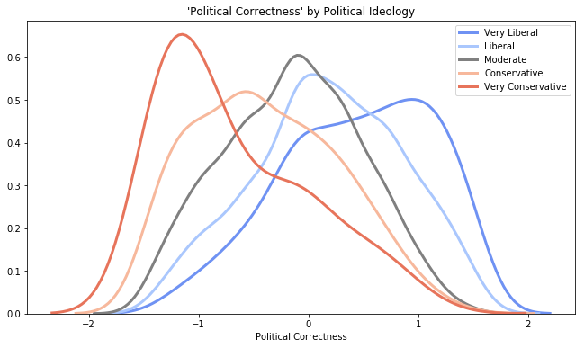

```python
# Plot FSI distribution by ideology and party affiliation
sns.set_palette('coolwarm', 5)
plt.rcParams["figure.figsize"] = (24, 6)
fig = plt.Figure()

ax = plt.subplot(1, 2, 1)
sns.distplot(very_lib_pc, ax=ax, hist=False, label='Very Liberal', kde_kws={'lw': 3})
sns.distplot(some_lib_pc, ax=ax, hist=False, label='Liberal', kde_kws={'lw': 3})
sns.distplot(d10_mod_pc, ax=ax, hist=False, label='Moderate', kde_kws={'lw': 3, 'color': 'gray'})
sns.distplot(some_cons_pc, ax=ax, hist=False, label='Conservative', kde_kws={'lw': 3})
sns.distplot(very_cons_pc, ax=ax, hist=False, label='Very Conservative', kde_kws={'lw': 3})
plt.title("'Political Correctness' by Political Ideology")
plt.xlabel('Political Correctness')
plt.legend()
```

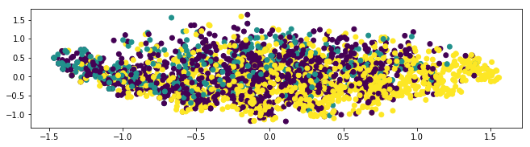

```python
# scatter first two principal components and color by ideological identification
# The first principal component is political correctness
ideo_cat = y.iloc[:,3].copy() + 1
ideo_cat.replace(1, y.iloc[:,5], inplace=True)

plt.subplot(2, 2, 1)
plt.scatter(df_pc.iloc[:,0], df_pc.iloc[:,1], c=ideo_cat)
plt.show()
```